# 02_hf

betts

2024-09-24

# 2024.szeptember 25. - Ökönometria házi feladat 2. - hotels - Stockholm

## 0.lépés - Előkészítés/Adattisztítás

### Az adatok megtisztításához és rendezéséhez szükséges lépések véghezvitele, mint a fájl hely beállítása, a packagek betöltése, az adatok beolvasása és betöltése.

```r
setwd("~/Documents/Documents - betts’s MacBook Air/rajk/kurzusok/2.félév/ökonometria/hf - 2")


#install.packages("ggthemes")
#install.packages("extrafont")

library(tidyverse)
library(dplyr)
library(scales)
library(xtable)
library(modelsummary)
library(ggthemes)
library(extrafont)
hotels_data <- read.csv("hotelbookingdata.csv")
```

### Az addresscountryname oszlopból előhívtam a változókat és azok alapján kiválasztottam Svédországot, mint célország. Utána előhívtam azokat a változókat a city_actual oszlopből, amelyek megfelelnek annak, hogy Svédországban találhatóak. Majd látva, hogy mely városokről van adat, kiválasztottam Stockholm-t, mint vizsgálandó város.

```r
print(unique(hotels_data$addresscountryname))
```

```
##  [1] "Netherlands"    "Greece"         "Spain"          "Serbia"
##  [5] "Germany"        "United Kingdom" "Slovakia"       "Belgium"
##  [9] "Romania"        "Cameroon"       "Hungary"        "Denmark"
## [13] "Ireland"        "Croatia"        "Finland"        "Turkey"
## [17] "Ukraine"        "Poland"         "Portugal"       "Egypt"
## [21] "France"         "Italy"          "Belarus"        "Russia"
## [25] "Cyprus"         "Czech Republic" "Latvia"         "Austria"
## [29] "Bulgaria"       "Sweden"         "Estonia"        "Malta"
## [33] "Lithuania"
```

```r
hotels_data %>%
  filter(addresscountryname == "Sweden") %>%
  pull(city_actual) %>%
  unique() %>%
  print()
```

```
##  [1] "Alvsjo"         "Arlanda"        "Arlandastad"    "Arsta"
##  [5] "Bromma"         "Danderyd"       "Enskede"        "Stockholm"
##  [9] "Hagersten"      "Huddinge"       "Jarfalla"       "Johanneshov"
## [13] "Kista"          "Kungens Kurva"  "Lidingo"        "Marsta"
## [17] "Nacka"          "Norsborg"       "Rosersberg"     "Saltsjobaden"
## [21] "Sigtuna"        "Skarholmen"     "Sollentuna"     "Solna"
## [25] "Spanga"         "Sundbyberg"     "Taby"           "Upplands Vasby"
## [29] "Vallingby"
```

### Az adatok szűrése kifejezetten a Stockholm-i hoteleket célozva a filter paranccsal.

```r
stockholm_data <- hotels_data %>%
  filter(city_actual == "Stockholm")
```

### Mivel az adattáblában egyszerre szerepelnek az 1 éjszakára és a 4 éjszakára vonatkozó árak, így megvizsgálom, hogy az egyes megfigyelésekből mennyi található és az alapján az egyik vagy a másik vagy mindekttő alapján fogom vizsgálni később az árak gyakoriságát.

```r
print(unique(hotels_data$price_night))
```

```
## [1] "price for 1 night"  "price for 4 nights"
```

```r
stockholm_data %>%
  filter(price_night == "price for 1 night") %>%
  count()
```

```
##      n
## 1 1145
```

```r
stockholm_data %>%
  filter(price_night == "price for 4 nights") %>%
  count()
```

```
##     n
## 1 124
```

### Mivel jelentősen több adat szerepel az 1 éjszakára vonatkozó adatokból, így később ezeken az adatokon fogok tovább dolgozni.

```r
stockholm_data$price_night <- recode(stockholm_data$price_night,
                                 "price for 1 night" = "1",
                                 "price for 4 nights" = "4",)

stockholm_data$price_night <- as.numeric(stockholm_data$price_night)

str(stockholm_data)
```

```
## 'data.frame':    1269 obs. of  24 variables:
##  $ addresscountryname    : chr  "Sweden" "Sweden" "Sweden" "Sweden" ...
##  $ city_actual           : chr  "Stockholm" "Stockholm" "Stockholm" "Stockholm" ...
##  $ rating_reviewcount    : int  212 212 212 212 212 212 212 212 212 212 ...
##  $ center1distance       : chr  "0.7 miles" "0.7 miles" "0.7 miles" "0.7 miles" ...
##  $ center1label          : chr  "City centre" "City centre" "City centre" "City centre" ...
##  $ center2distance       : chr  "1.3 miles" "1.3 miles" "1.3 miles" "1.3 miles" ...
##  $ center2label          : chr  "Eriksdalsbadet" "Eriksdalsbadet" "Eriksdalsbadet" "Eriksdalsbadet" ...
##  $ neighbourhood         : chr  "Gamla Stan" "Gamla Stan" "Gamla Stan" "Gamla Stan" ...
##  $ price                 : int  73 73 276 59 179 69 73 69 69 73 ...
##  $ price_night           : num  1 1 4 1 1 1 1 1 1 1 ...
##  $ s_city                : chr  "Stockholm" "Stockholm" "Stockholm" "Stockholm" ...
##  $ starrating            : num  2 2 2 2 2 2 2 2 2 2 ...
##  $ rating2_ta            : num  4 4 4 4 4 4 4 4 4 4 ...
##  $ rating2_ta_reviewcount: int  224 224 224 224 224 224 224 224 224 224 ...
##  $ accommodationtype     : chr  "_ACCOM_TYPE@Hostel" "_ACCOM_TYPE@Hostel" "_ACCOM_TYPE@Hostel" "_ACCOM_TYPE@Hostel" ...
##  $ guestreviewsrating    : chr  "3.7 /5" "3.7 /5" "3.7 /5" "3.7 /5" ...
##  $ scarce_room           : int  0 0 1 1 1 1 0 1 0 0 ...
##  $ hotel_id              : int  21547 21547 21547 21547 21547 21547 21547 21547 21547 21547 ...
##  $ offer                 : int  0 0 0 0 0 0 0 0 0 0 ...
##  $ offer_cat             : chr  "0% no offer" "0% no offer" "0% no offer" "0% no offer" ...
##  $ year                  : int  2018 2018 2017 2017 2017 2018 2018 2017 2018 2018 ...
##  $ month                 : int  6 3 12 11 11 5 4 12 1 2 ...
##  $ weekend               : int  1 1 0 0 1 1 1 0 1 1 ...
##  $ holiday               : int  0 0 1 0 0 0 0 1 0 0 ...
```

### Számomra nem volt egyértelmű 3 oszlopnak az elnevezése, így a center1distance & center2label & center2distance oszlopokat átnevezem, citycenter_distance & sightname & sight_distance nevű oszlopokra.

```r
stockholm_data <- stockholm_data %>%
  rename(citycenter_distance = center1distance) %>%
  rename(sightname = center2label) %>%
  rename(sight_distance = center2distance)
```

### Az “identical” paranccsal megnézem, hogy a két oszlopomban megegyeznek-e az értékek és azonos sorrendben vannak-e. Ha lefuttatás után “TRUE” értéket kapok, akkor a két tábla megegyezik egymással.

```r
identical(stockholm_data$city_actual, stockholm_data$s_city)
```

```
## [1] TRUE
```

### A “select” paranccsal kiválasztom azokat az oszlopokat, amelyek szükségesek és új sorrendbe rakom őket.

```r
stockholm_data <- stockholm_data %>%
  select(addresscountryname, city_actual, neighbourhood, hotel_id, price, price_night, accommodationtype, citycenter_distance, sightname, sight_distance, offer, starrating, guestreviewsrating, rating_reviewcount, rating2_ta, rating2_ta_reviewcount, scarce_room, offer, offer_cat, year, month, weekend, holiday)
```

### A nem intuitív változó/oszlopnevek egyszerűsítése a könnyebb adatértelmezés érdekében. Az adatok vizsgálata közben kijött, hogy az accommodationtype oszlop változó értékeinek elnevezése nem rögtön egyértelmű, így a “unique” paranccsal összegyűjtöm az összes változót az oszlopban, hogy könnyebben át tudjam nevezni őket. A 7 változómat leegyszerűsítés miatt “recode” paranccsal átnevezem.

```r
print(unique(stockholm_data$accommodationtype))
```

```
## [1] "_ACCOM_TYPE@Hostel"            "_ACCOM_TYPE@Hotel"
## [3] "_ACCOM_TYPE@Apartment"         "_ACCOM_TYPE@Apart-hotel"
## [5] "_ACCOM_TYPE@Bed and breakfast" "_ACCOM_TYPE@House boat"
## [7] "_ACCOM_TYPE@Guest House"
```

```r
stockholm_data <- stockholm_data %>% mutate(accommodationtype = as.factor(accommodationtype))

stockholm_data$accommodationtype <- recode(stockholm_data$accommodationtype,
                                 "_ACCOM_TYPE@Hotel" = "Hotel",
                                 "_ACCOM_TYPE@Apart-hotel" = "Apart-hotel",
                                 "_ACCOM_TYPE@Guest House" = "Guest House",
                                 "_ACCOM_TYPE@Bed and breakfast" = "Bed and breakfast",
                                 "_ACCOM_TYPE@House boat"  = "House boat",
                                 "_ACCOM_TYPE@Hostel" = "Hostel",
                                 "_ACCOM_TYPE@Apartment" = "Apartment",)
```

### 4 változó esetén az is felmerült, hogy az az értékek nem numerikusak, mivel a számok mögött szöveg is található, így ezeknél a “gsub” paranccsal kiszedem a szövegeket és numerikussá vektorrá alakítom. A 4 oszlop amelyben változásokat fogok bevezetni a citycenter_distance & sight_distance & guestreviewsrating & offer_cat.

### Megnézem, hogy a oszlopok milyen típusként vannak az adattáblában és ha kell javítok/kicserélem az értelmezésüket. Pl.: Ha egy numerikus változós oszlop karakter típusú, akkor numerikussá változtatom.

```r
stockholm_data$citycenter_distance <- gsub(" miles| mile", "", stockholm_data$citycenter_distance)
stockholm_data$citycenter_distance <- as.numeric(stockholm_data$citycenter_distance)

stockholm_data$sight_distance <- gsub(" miles| mile", "", stockholm_data$sight_distance)
stockholm_data$sight_distance <- as.numeric(stockholm_data$sight_distance)

stockholm_data$guestreviewsrating <- gsub(" /5", "", stockholm_data$guestreviewsrating)
stockholm_data$guestreviewsrating <- as.numeric(stockholm_data$guestreviewsrating)

stockholm_data$offer_cat <- gsub(" offer| no offer", "", stockholm_data$offer_cat)

str(stockholm_data)
```

```
## 'data.frame':    1269 obs. of  22 variables:
##  $ addresscountryname    : chr  "Sweden" "Sweden" "Sweden" "Sweden" ...
##  $ city_actual           : chr  "Stockholm" "Stockholm" "Stockholm" "Stockholm" ...
##  $ neighbourhood         : chr  "Gamla Stan" "Gamla Stan" "Gamla Stan" "Gamla Stan" ...
##  $ hotel_id              : int  21547 21547 21547 21547 21547 21547 21547 21547 21547 21547 ...
##  $ price                 : int  73 73 276 59 179 69 73 69 69 73 ...
##  $ price_night           : num  1 1 4 1 1 1 1 1 1 1 ...
##  $ accommodationtype     : Factor w/ 7 levels "Apart-hotel",..: 5 5 5 5 5 5 5 5 5 5 ...
##  $ citycenter_distance   : num  0.7 0.7 0.7 0.7 0.7 0.7 0.7 0.7 0.7 0.7 ...
##  $ sightname             : chr  "Eriksdalsbadet" "Eriksdalsbadet" "Eriksdalsbadet" "Eriksdalsbadet" ...
##  $ sight_distance        : num  1.3 1.3 1.3 1.3 1.3 1.3 1.3 1.3 1.3 1.3 ...
##  $ offer                 : int  0 0 0 0 0 0 0 0 0 0 ...
##  $ starrating            : num  2 2 2 2 2 2 2 2 2 2 ...
##  $ guestreviewsrating    : num  3.7 3.7 3.7 3.7 3.7 3.7 3.7 3.7 3.7 3.7 ...
##  $ rating_reviewcount    : int  212 212 212 212 212 212 212 212 212 212 ...
##  $ rating2_ta            : num  4 4 4 4 4 4 4 4 4 4 ...
##  $ rating2_ta_reviewcount: int  224 224 224 224 224 224 224 224 224 224 ...
##  $ scarce_room           : int  0 0 1 1 1 1 0 1 0 0 ...
##  $ offer_cat             : chr  "0%" "0%" "0%" "0%" ...
##  $ year                  : int  2018 2018 2017 2017 2017 2018 2018 2017 2018 2018 ...
##  $ month                 : int  6 3 12 11 11 5 4 12 1 2 ...
##  $ weekend               : int  1 1 0 0 1 1 1 0 1 1 ...
##  $ holiday               : int  0 0 1 0 0 0 0 1 0 0 ...
```

```r
stockholm_data$hotel_id <- as.factor(stockholm_data$hotel_id)
```

### Ellenőriztem, hogy vannak-e az adattáblában hiányzó adatok, és ha igen hol.

```r
any(is.na(stockholm_data))
```

```
## [1] TRUE
```

```r
#Mivel "TRUE" értéket kaptam, ezért van hiányzó adat az adattáblában. A "colSums" paranccsal összegyűjtöm melyik oszlopban vannak hiányzó adatok és mennyi.

colSums(is.na(stockholm_data))
```

```
##     addresscountryname            city_actual          neighbourhood
##                      0                      0                      0
##               hotel_id                  price            price_night
##                      0                      0                      0
##      accommodationtype    citycenter_distance              sightname
##                      0                      0                      0
##         sight_distance                  offer             starrating
##                      0                      0                      0
##     guestreviewsrating     rating_reviewcount             rating2_ta
##                     10                     10                     16
## rating2_ta_reviewcount            scarce_room              offer_cat
##                     16                      0                      0
##                   year                  month                weekend
##                      0                      0                      0
##                holiday
##                      0
```

### Mivel a hiányzó adatok nem árral és távolsággal kapcsolatosak, emiatt nem befolyásolja a kesőbbi adatvizsgálatomat, így nem helyettesítem/törlöm ki őket.

## 1.lépés - Árak és távolságok eloszlása a Stockholm-i hotelek fókuszában

### Megvizsgálom, hogy az éjszakák hány napra szólnak és az alapján szétbontom több változóra, hogy majd az ábrák létrehozásánál csak azokat az adatokat tudjam vizsgálni, ahol az ár egy éjszakára szól.

```r
hotel_stockholm <- stockholm_data %>% filter(accommodationtype=="Hotel")

hotel_stockholm <- hotel_stockholm %>% filter(price_night == 1)
```

### Létrehozok egy hisztogramot az alapján, hogy milyen ár gyakorisággal szerepelnek hotelek, amelyeknek 1 éjszakára szól az ajánlatuk Stockholm-ban.

```r
table(hotel_stockholm$price)
```

```
##
##   58   65   69   71   76   77   78   80   81   82   83   84   85   86   87   89
##    1    2    1    2    2    1    2    7    4    1   10    5    2    2    2    1
##   90   91   92   93   94   95   96   97   98  100  101  102  103  104  105  106
##    2    1    5    1    8    4    2    1    1    4    4    2    3    4    1    9
##  107  108  109  111  112  113  114  115  116  117  118  119  120  121  122  123
##    3    1    3    2    3   17    7    8    5    8   12    4    1    3   11   13
##  124  125  126  127  128  129  130  131  132  133  134  135  136  137  138  139
##    3   10   14   11    3    7   18    4    6    7    2    1    2    4   13    2
##  140  141  142  143  144  145  146  147  148  149  150  151  152  153  154  155
##    3    3   11    8    6   14    1    9    3   12    5    4    7    3   14   10
##  156  157  158  159  160  161  162  163  164  165  166  167  168  170  171  172
##    5    1    3    5    5   14    4    3    5    3   21    4    3   10   14    1
##  173  174  176  177  178  179  180  181  182  184  185  186  187  188  189  190
##    7    3    6   13   11    3    4   22    9    2    5    1    2    7    6    9
##  191  192  194  195  196  197  198  199  200  201  202  203  204  208  209  210
##    3   11    2    4    1    2    3    1    5    8    8    8    2    3    7    1
##  212  213  214  215  216  217  218  219  220  222  223  224  225  228  230  231
##    3    6    6    1    1    1    5    1    2    5    4    7   10    1    1    3
##  232  233  234  235  236  237  238  240  241  243  244  246  247  248  249  250
##    1    2    1    5    3    1    8    1    2    4    1    4    2    1    3    1
##  251  252  253  254  255  256  257  261  262  264  265  266  267  268  270  271
##    1    7    2    1    1    3    3    3    5    1    1    2    3    1    1    4
##  273  274  278  280  283  284  285  286  289  293  297  298  300  302  303  305
##    4    3    2    2    3    5    2    4    3    5    3    3    1    1    1    3
##  306  308  309  310  311  321  323  324  327  332  334  343  346  349  353  354
##    1    1    5    3    2    4    1    4    1    1    2    1    1    1    2    4
##  357  369  370  372  375  381  392  405  465  549  578  644 1313
##    2    1    1    2    1    3    1    1    1    1    1    1    1
```

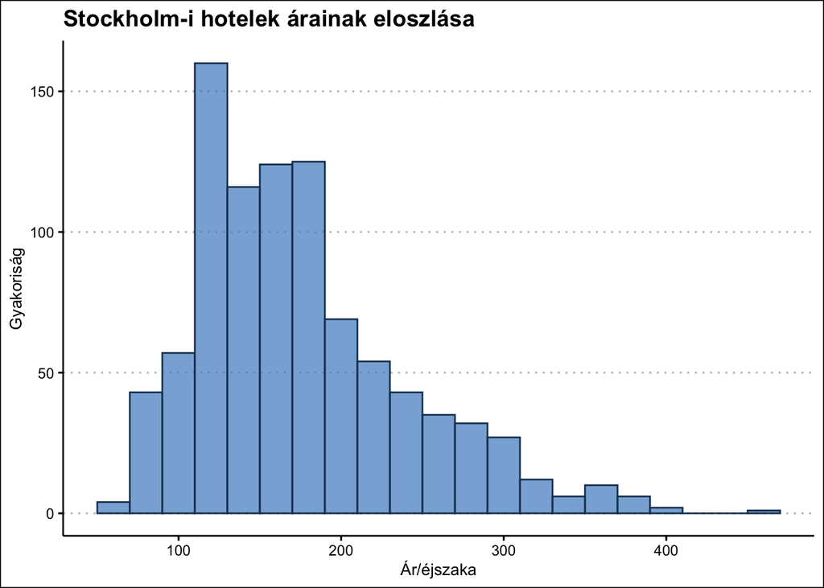

```r
hotel_stockholm %>%
  filter(price<=500) %>%
  ggplot(aes(x = price)) +
  geom_histogram(binwidth = 20, color="#1c3e5d", fill = "#4b8cc8", alpha = 0.7) +
  labs(title = "Stockholm-i hotelek árainak eloszlása", x = "Ár/éjszaka", y = "Gyakoriság") +
  theme_clean() +
  theme(text = element_text(family = "Arial"))
```

### Annak érdekében, hogy az ábra könnyebben érthető legyen a szélső értékeket nem prezentáltam a hisztogrammon. Emiatt az 500 EUR-nál drágább hotelek nem jelennek meg az ábrán (4 db megfigyelés lett kizárva a szélsőséges értékekkel való szűkítés miatt).

### A Hisztogramhoz egy sűrűséggörbét is csatolok.

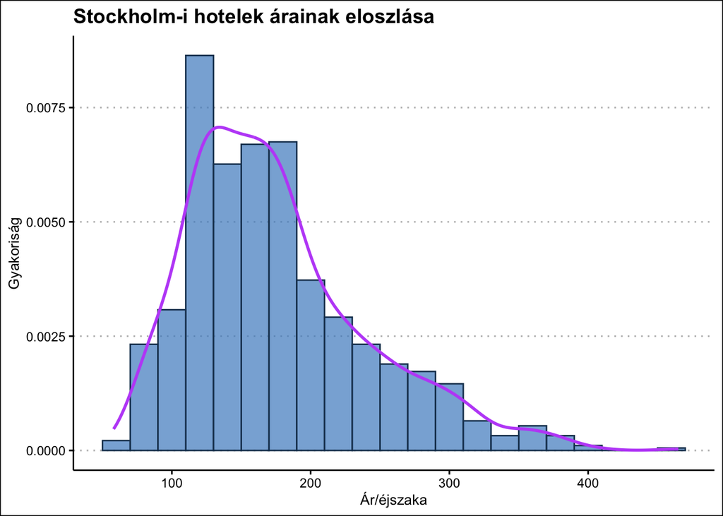

```r
hotel_stockholm %>%
  filter(price<=500) %>%
  ggplot(aes(x = price)) +
  geom_histogram(aes(y = ..density..), binwidth = 20, color="#1c3e5d", fill = "#4b8cc8", alpha = 0.7) +
  geom_density(color = "#bf57f7", size = 1) +
  labs(title = "Stockholm-i hotelek árainak eloszlása", x = "Ár/éjszaka", y = "Gyakoriság") +
  theme_clean() +
  theme(text = element_text(family = "Arial"))
```

### Létrehozok egy másik hisztogramot az alapján, hogy milyen távolság gyakorisággal szerepelnek hotelek, amelyeknek 1 éjszakára szól az ajánlatuk Stockholm-ban.

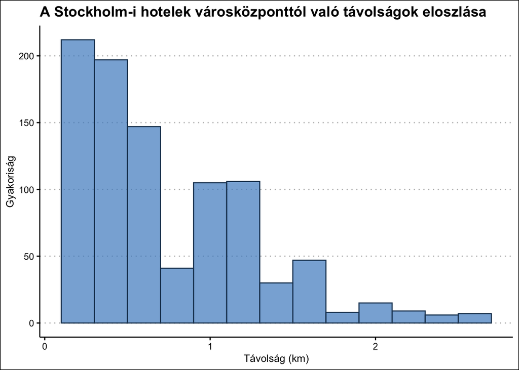

```r
ggplot(hotel_stockholm, aes(x = citycenter_distance)) +
  geom_histogram(binwidth = 0.2, fill = "#4b8cc8", color = "#1c3e5d", alpha = 0.7) +
  labs(title = "A Stockholm-i hotelek városközponttól való távolságok eloszlása", x = "Távolság (km)", y = "Gyakoriság") +
  theme_clean()+
  theme(text = element_text(family = "Arial"))
```

### A Hisztogramhoz egy sűrűséggörbét is csatolok.

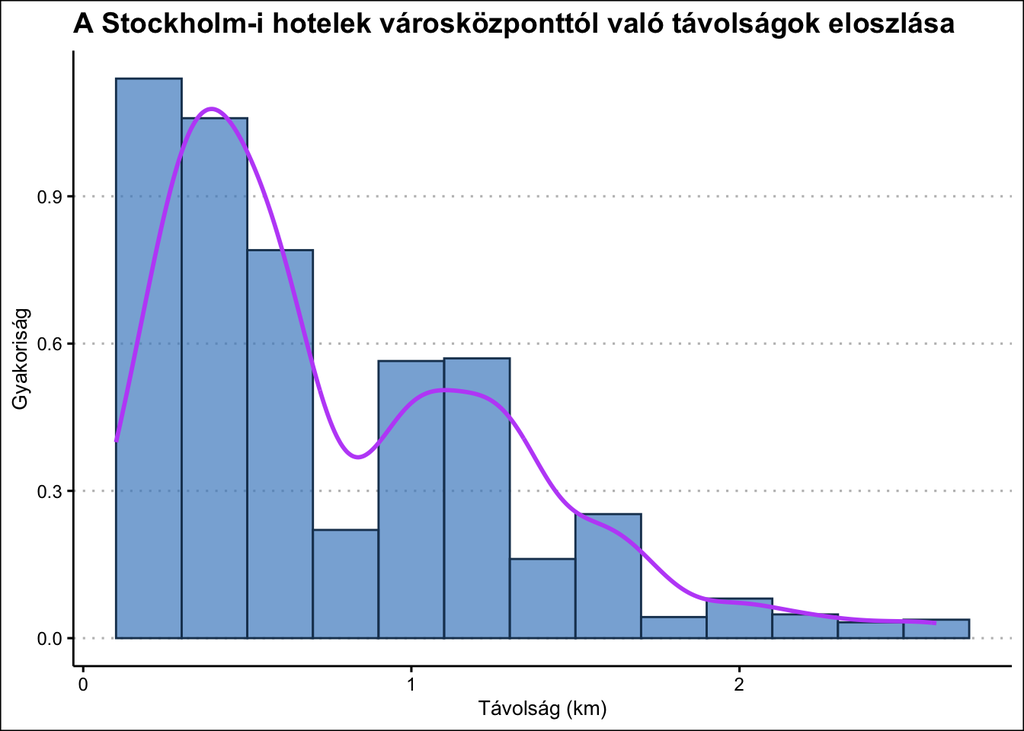

```r
ggplot(hotel_stockholm, aes(x = citycenter_distance)) +
  geom_histogram(aes(y = ..density..), binwidth = 0.2, fill = "#4b8cc8", color = "#1c3e5d", alpha = 0.7) +
  geom_density(color = "#bf57f7", size = 1) +
  labs(title = "A Stockholm-i hotelek városközponttól való távolságok eloszlása", x = "Távolság (km)", y = "Gyakoriság") +
  theme_clean()+
  theme(text = element_text(family = "Arial"))
```

## 2.lépés - Leíró statisztikák

```r
summary(hotel_stockholm$price)
```

```
##    Min. 1st Qu.  Median    Mean 3rd Qu.    Max.
##    58.0   127.0   165.0   178.5   209.8  1313.0
```

```r
summary(hotel_stockholm$citycenter_distance)
```

```
##    Min. 1st Qu.  Median    Mean 3rd Qu.    Max.
##  0.1000  0.4000  0.6000  0.7832  1.1000  2.6000
```

```r
var(hotel_stockholm$price)
```

```
## [1] 6178.321
```

```r
sd(hotel_stockholm$price)
```

```
## [1] 78.6023
```

## 3.0.lépés - a Bécsi adatok előkészítése a későbbi összehasonlításhoz, a Stockholmi hotelek adatainak előkészítéséhez hasonlóan

```r
vienna_data <- hotels_data %>%
  filter(city_actual == "Vienna")

print(unique(vienna_data$price_night))
```

```
## [1] "price for 1 night"  "price for 4 nights"
```

```r
vienna_data %>%
  filter(price_night == "price for 1 night") %>%
  count()
```

```
##      n
## 1 3276
```

```r
vienna_data %>%
  filter(price_night == "price for 4 nights") %>%
  count()
```

```
##     n
## 1 320
```

```r
vienna_data$price_night <- recode(vienna_data$price_night,
                                 "price for 1 night" = "1",
                                 "price for 4 nights" = "4",)

vienna_data$price_night <- as.numeric(vienna_data$price_night)

vienna_data <- vienna_data %>% filter(price_night == 1)

vienna_data <- vienna_data %>%
  rename(citycenter_distance = center1distance) %>%
  rename(sightname = center2label) %>%
  rename(sight_distance = center2distance)

identical(vienna_data$city_actual, vienna_data$s_city)
```

```
## [1] TRUE
```

```r
vienna_data <- vienna_data %>%
  select(addresscountryname, city_actual, neighbourhood, hotel_id, price, price_night, accommodationtype, citycenter_distance, sightname, sight_distance, offer, starrating, guestreviewsrating, rating_reviewcount, rating2_ta, rating2_ta_reviewcount, scarce_room, offer, offer_cat, year, month, weekend, holiday)


vienna_data$accommodationtype <- recode(vienna_data$accommodationtype,
                                  "_ACCOM_TYPE@Hotel" = "Hotel",
                                 "_ACCOM_TYPE@Apart-hotel" = "Apart-hotel",
                                 "_ACCOM_TYPE@Guest House" = "Guest House",
                                 "_ACCOM_TYPE@Bed and breakfast"   = "Bed and breakfast",
                                 "_ACCOM_TYPE@House boat"  = "House boat",
                                 "_ACCOM_TYPE@Hostel" = "Hostel",
                                 "_ACCOM_TYPE@Apartment" = "Apartment",)

vienna_data$citycenter_distance <- gsub(" miles| mile", "", vienna_data$citycenter_distance)
vienna_data$citycenter_distance <- as.numeric(vienna_data$citycenter_distance)

vienna_data$sight_distance <- gsub(" miles| mile", "", vienna_data$sight_distance)
vienna_data$sight_distance <- as.numeric(vienna_data$sight_distance)

vienna_data$guestreviewsrating <- gsub(" /5", "", vienna_data$guestreviewsrating)
vienna_data$guestreviewsrating <- as.numeric(vienna_data$guestreviewsrating)

vienna_data$offer_cat <- gsub(" offer| no offer", "", vienna_data$offer_cat)

vienna_data$hotel_id <- as.factor(vienna_data$hotel_id)

any(is.na(vienna_data))
```

```
## [1] TRUE
```

```r
colSums(is.na(vienna_data))
```

```
##     addresscountryname            city_actual          neighbourhood
##                      0                      0                      0
##               hotel_id                  price            price_night
##                      0                      0                      0
##      accommodationtype    citycenter_distance              sightname
##                      0                      0                      0
##         sight_distance                  offer             starrating
##                      0                      0                      0
##     guestreviewsrating     rating_reviewcount             rating2_ta
##                    271                    271                    916
## rating2_ta_reviewcount            scarce_room              offer_cat
##                    916                      0                      0
##                   year                  month                weekend
##                      0                      0                      0
##                holiday
##                      0
```

```r
vienna_data <- vienna_data %>% filter(accommodationtype=="Hotel")
```

## 3.1.lépés - a releváns ábrák elkészítése a Bécsi hotelek adatait felhasználva

### Létrehozok egy hisztogramot az alapján, hogy milyen ár gyakorisággal szerepelnek hotelek, amelyeknek 1 éjszakára szól az ajánlatuk Bécsben és az ábrára sűrűséggörbét is teszek.

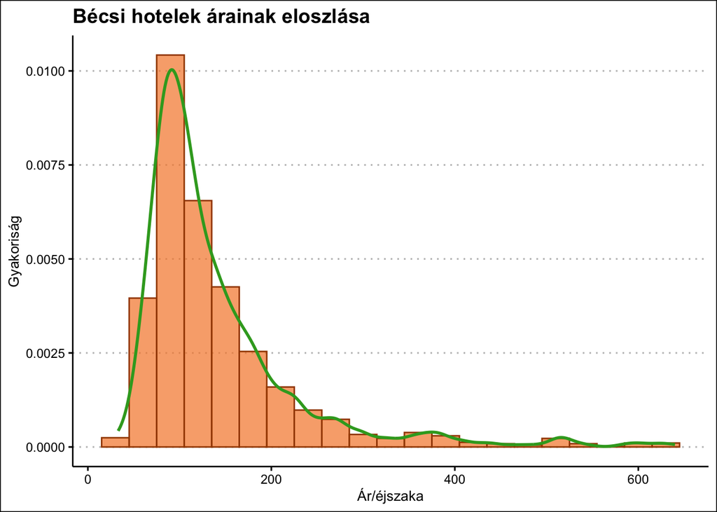

```r
vienna_data %>%
  filter(price<=650) %>%
  ggplot(aes(x = price)) +
  geom_histogram(aes(y = ..density..), binwidth = 30, color="#a34700", fill = "#f58631", alpha = 0.7) +
  geom_density(color = "#37a626", size = 1) +
  labs(title = "Bécsi hotelek árainak eloszlása", x = "Ár/éjszaka", y = "Gyakoriság") +
  theme_clean() +
  theme(text = element_text(family = "Arial"))
```

### Annak érdekében, hogy az ábra könnyebben érthető legyen a szélső értékeket nem prezentáltam a hisztogrammon. Emiatt az 650 EUR-nál drágább hotelek nem jelennek meg az ábrán (12 db megfigyelés lett kizárva a szélsőséges értékekkel való szűkítés miatt).

### Létrehozok egy másik hisztogramot az alapján, hogy milyen távolság gyakorisággal szerepelnek hotelek, amelyeknek 1 éjszakára szól az ajánlatuk Bécsben és az ehhez tartozó sűrűséggörbét is ábrázolom.

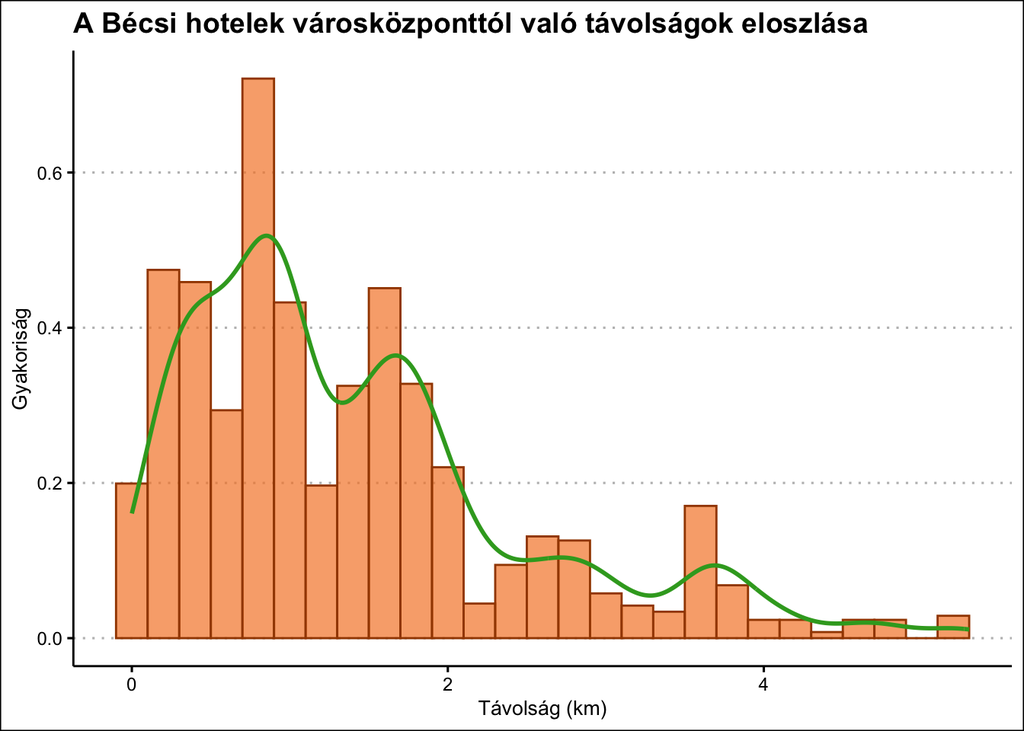

```r
vienna_data %>%
  filter(citycenter_distance <= 6) %>%
  ggplot(aes(x = citycenter_distance)) +
  geom_histogram(aes(y = ..density..), binwidth = 0.2, fill = "#f58631", color = "#a34700", alpha = 0.7) +
  geom_density(color = "#37a626", size = 1) +
  labs(title = "A Bécsi hotelek városközponttól való távolságok eloszlása", x = "Távolság (km)", y = "Gyakoriság") +
  theme_clean()+
  theme(text = element_text(family = "Arial"))
```

## 3.2.lépés - Leíró statisztikák

```r
summary(vienna_data$price)
```

```
##    Min. 1st Qu.  Median    Mean 3rd Qu.    Max.
##    33.0    87.0   113.0   145.2   163.0  1012.0
```

```r
summary(vienna_data$citycenter_distance)
```

```
##    Min. 1st Qu.  Median    Mean 3rd Qu.    Max.
##   0.000   0.600   1.100   1.441   1.900   6.600
```

```r
var(vienna_data$price)
```

```
## [1] 11266.12
```

```r
sd(vienna_data$price)
```

```
## [1] 106.142
```

## 4.lépés -Szélső értékek

### Fontos megjegyezni, hogy egyik esetben sem vettem ki az adattábláimból ezeket a szélsőséges értékeket, csakis az ábrák könnyebb megértése miatt szűrtem ki az aktuális ábrakészítésnél.

### Mivel nem gondolom, hogy ezek az adatok hibásak lennének, így nem törlöm a szélső értékeknek vélt adatokat. Viszont, hogy az ábrák intuitívabbak legyenek, ezért exkludálom őket az adatábrázolás folyamtakor.

## 5.lépés - a Stockholm-i hotelekkel kapcsolatos értékek összehasonlítása a Bécsi hotelekkel kapcsolatos értékekkel

### 5.1. A Stockholm-i és Bécsi adatok kombinálása és az adatok összehasonlítása egy közös hisztogrammon.

### Létrehozok egy hisztogramot az alapján, hogy milyen ár gyakorisággal szerepelnek hotelek, amelyeknek 1 éjszakára szól az ajánlatuk Stockholm-ban és Bécsben.

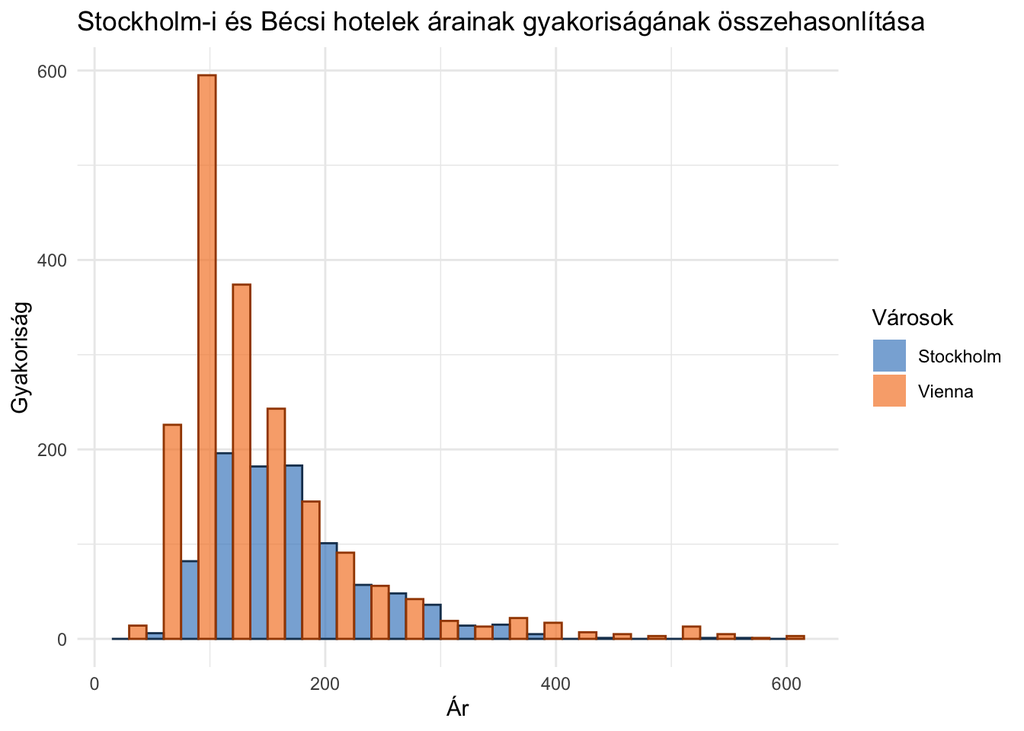

```r
combined_hotel <- rbind(hotel_stockholm, vienna_data)

combined_hotel %>%
  filter(price<=600) %>%
  ggplot (aes(x = price, fill = city_actual, color = city_actual)) +
  geom_histogram(position = "dodge", binwidth = 30, alpha = 0.7) +
  labs(title = "Stockholm-i és Bécsi hotelek árainak gyakoriságának összehasonlítása",
       x = "Ár",
       y = "Gyakoriság",
       fill = "Városok") +
  scale_fill_manual(values = c("#4b8cc8", "#f58631")) +
  scale_color_manual(values = c("#1c3e5d", "#a34700")) +
  guides(color = "none") +
  theme_minimal() +
  theme(text = element_text(family = "Arial"))
```

### Létrehozok egy másik hisztogramot az alapján, hogy milyen távolság gyakorisággal szerepelnek hotelek, amelyeknek 1 éjszakára szól az ajánlatuk Stockholm-ban és Bécsben.

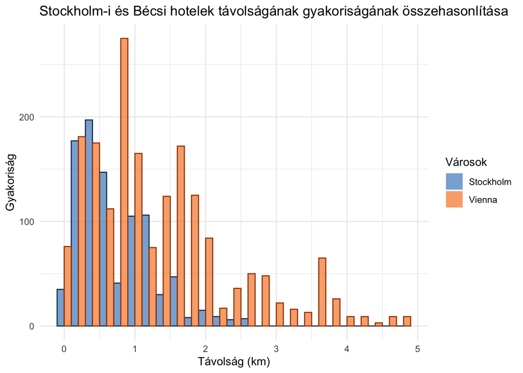

```r
  combined_hotel %>%
  filter( citycenter_distance <= 5) %>%
  ggplot (aes(x = citycenter_distance, fill = city_actual, color = city_actual)) +
  geom_histogram(position = "dodge", binwidth = 0.2, alpha = 0.7) +
  labs(title = "Stockholm-i és Bécsi hotelek távolságának gyakoriságának összehasonlítása",
       x = "Távolság (km)",
       y = "Gyakoriság",
       fill = "Városok") +
  scale_fill_manual(values = c("#4b8cc8", "#f58631")) +
  scale_color_manual(values = c("#1c3e5d", "#a34700")) +
  guides(color = "none") +
  theme_minimal() +
  theme(text = element_text(family = "Arial"))
```

### 5.2. Leíró statisztikák összehasonlítása

```r
#Stockholm:
summary(hotel_stockholm$price)
```

```
##    Min. 1st Qu.  Median    Mean 3rd Qu.    Max.
##    58.0   127.0   165.0   178.5   209.8  1313.0
```

```r
summary(hotel_stockholm$citycenter_distance)
```

```
##    Min. 1st Qu.  Median    Mean 3rd Qu.    Max.
##  0.1000  0.4000  0.6000  0.7832  1.1000  2.6000
```

```r
var(hotel_stockholm$price)
```

```
## [1] 6178.321
```

```r
sd(hotel_stockholm$price)
```

```
## [1] 78.6023
```

```r
#Bécs:
summary(vienna_data$price)
```

```
##    Min. 1st Qu.  Median    Mean 3rd Qu.    Max.
##    33.0    87.0   113.0   145.2   163.0  1012.0
```

```r
summary(vienna_data$citycenter_distance)
```

```
##    Min. 1st Qu.  Median    Mean 3rd Qu.    Max.
##   0.000   0.600   1.100   1.441   1.900   6.600
```

```r
var(vienna_data$price)
```

```
## [1] 11266.12
```

```r
sd(vienna_data$price)
```

```
## [1] 106.142
```

### Az is kiderül az adatokból, hogy Stockholmban a hotelek jóval közelebb helyezkednek el a városközponthoz átlagosan, mint Bécsben. Ennek egyik oka lehet, hogy Bécs alapterülete 414,6 km^2, míg Stockholm-é 188 km^2.